# 3일차

```python
import pandas as pd

df = pd.read_csv('test1.csv')
```

```python
df
```

|  | datetime | season | holiday | workingday | weather | temp | atemp | humidity | windspeed | casual | registered | count |
| --- | --- | --- | --- | --- | --- | --- | --- | --- | --- | --- | --- | --- |
| 0 | 2011-01-01 00:00:00 | 1 | 0 | 0 | 1 | 9.84 | 14.395 | 81 | 0.0000 | 3 | 13 | 16 |
| 1 | 2011-01-01 01:00:00 | 1 | 0 | 0 | 1 | 9.02 | 13.635 | 80 | 0.0000 | 8 | 32 | 40 |
| 2 | 2011-01-01 02:00:00 | 1 | 0 | 0 | 1 | 9.02 | 13.635 | 80 | 0.0000 | 5 | 27 | 32 |
| 3 | 2011-01-01 03:00:00 | 1 | 0 | 0 | 1 | 9.84 | 14.395 | 75 | 0.0000 | 3 | 10 | 13 |
| 4 | 2011-01-01 04:00:00 | 1 | 0 | 0 | 1 | 9.84 | 14.395 | 75 | 0.0000 | 0 | 1 | 1 |
| ... | ... | ... | ... | ... | ... | ... | ... | ... | ... | ... | ... | ... |
| 10881 | 2012-12-19 19:00:00 | 4 | 0 | 1 | 1 | 15.58 | 19.695 | 50 | 26.0027 | 7 | 329 | 336 |
| 10882 | 2012-12-19 20:00:00 | 4 | 0 | 1 | 1 | 14.76 | 17.425 | 57 | 15.0013 | 10 | 231 | 241 |
| 10883 | 2012-12-19 21:00:00 | 4 | 0 | 1 | 1 | 13.94 | 15.910 | 61 | 15.0013 | 4 | 164 | 168 |
| 10884 | 2012-12-19 22:00:00 | 4 | 0 | 1 | 1 | 13.94 | 17.425 | 61 | 6.0032 | 12 | 117 | 129 |
| 10885 | 2012-12-19 23:00:00 | 4 | 0 | 1 | 1 | 13.12 | 16.665 | 66 | 8.9981 | 4 | 84 | 88 |

10886 rows × 12 columns

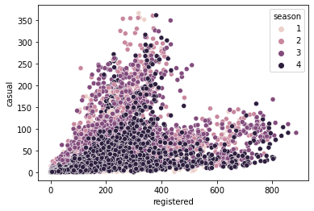

```python
import seaborn as sns

sns.scatterplot(data=df, x='registered', y='casual', hue='season')
```

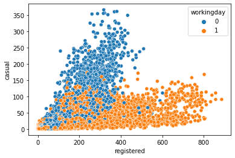

```python
# Q1) 일하는 날과 일하지 않는 날에 따라 등록 회원과 비등록 회원의 사용하는 날의 차이가
#    있을것으로 예상된다. 이에 대한 그래프를 그리세요.


sns.scatterplot(data=df, x='registered', y='casual', hue='workingday')

# 일하는 날에는 등록 회원이 많이 이용하고, 일하지 않는 날은 비등록 회원이 많이 이용함
# 등록 회원과 비등록 회원이 사용하는 빈도의 차이는 일하는 날과 일하지 않는 날의 차이


# 데이터를 표현하고, 해석하는 그림을 통해 데이터를 잘 표현하는 문장 도출
# 그림을 해석하여 문장을 도출해 낼 수 있어야 하고, 그 문장의 의미가 있어야 함
```

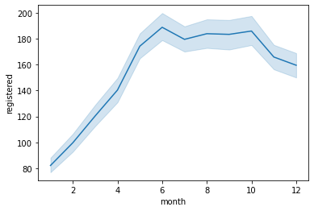

```python
# Q2) 월별 등록 회원의 이용량 그래프를 작성하세요.(lineplot)

df = pd.read_csv('test1_modify.csv')
sns.lineplot(data=df, x='month', y='registered')
```

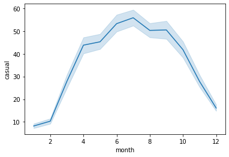

```python
# Q3) 월별 비등록 회원의 이용량 그래프를 작성하고, 등록 회원과 비등록 회원의
#     월별 사용편차에 대해 기술하세요.

sns.lineplot(data=df, x='month', y='casual')

# A) 등록 회원에 비해 비등록 회원은 월별 사용편차가 좀 더 심하다.
```

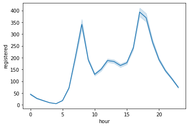

```python
# Q4) 사람의 행동패턴에 가장 큰 영향을 미치는 것은 시간이다.
#     시간대별 회원들의 패턴을 기술하세요.

# 등록 회원의 시간대별 이용량
sns.lineplot(data=df, x='hour', y='registered')
```

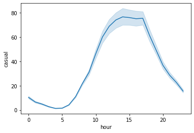

```python
# 비등록 회원의 시간대별 이용량
sns.lineplot(data=df, x='hour', y='casual')

# A)
# 등록회원은 출근 시간대와 퇴근 시간대에 사용량이 빈번하고,
# 비등록 회원은 점심 시간대(11~16)에 사용량이 빈번하다.
# 즉 등록 회원과 비등록 회원은 사용 의도와 목적이 다를 것이다.
```

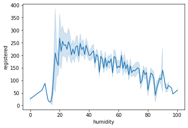

```python
# Q5) 습도에 따른 이용량에 대해 기술하세요.

sns.lineplot(data=df, x='humidity', y='registered')

# A) 습도가 매우 낮거나 높아질수록 사용량이 떨어진다.
#    즉, 불쾌지수가 높으면 사용량이 줄어든다.
```

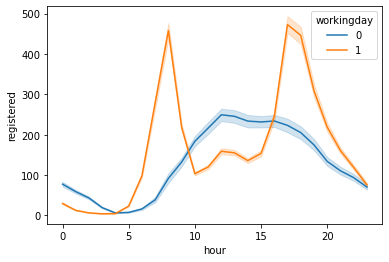

```python
# Q6) Q4에서 일하는 날과 노는 날을 기준으로
# 일하는 날에서만 나타나는 패턴인지, 일 안하는 날에도 똑같은 패턴인지 확인하세요.

sns.lineplot(data=df, x='hour', y='registered', hue='workingday')

# 등록회원은 일하는 날과 일하지 않는 날의 목적이 다르게 보임
```

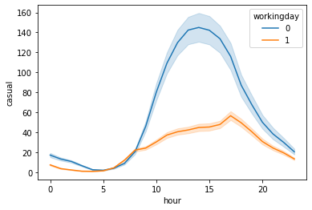

```python
sns.lineplot(data=df, x='hour', y='casual', hue='workingday')

# 비등록 회원은 일하는 날에 거의 활용하지 않고, 노는 날에 사용량이 높음
# A)
# 전반적으로 일하는 날과 노는 날의 차이가 보인다.
# 등록 회원: 일하는 날 출근 시간대와 퇴근 시간대 이용량이 높고,
# 노는 날엔 상반된 결과를 보임
# 비등록 회원: 일하는 날 사용량이 낮고, 노는 날 점심 시간대에 이용량이 가장 높음
```

## 데이터 분석 절차, 단계, 방법론

- 체계화된 절차와 방법이 정리된 분석 방법론이 필요
- 방법론은 절차와 방법, 도구, 기법, 템플릿과 산출물로 구성되어 있으며, 활용하기 쉽도록 구성되어야 함
- 절차와 방법론은 다양하게 존재함
- 전통적 데이터분석 방법론: KDD, CRISP-DM

## CRISP-DM

- Cross-Industry Standard Process - Data-Mining
- 가장 많이 사용되는 Data Mining 표준 방법론
- 분야, 산업군을 막론하고 데이터로부터 의미를 도출하는 표준 절차

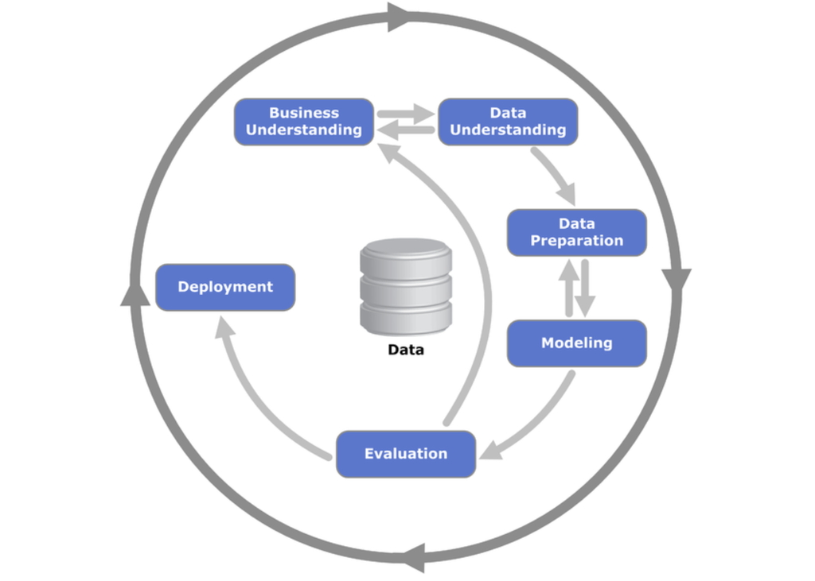

## Business Understanding(업무 이해)

- 분석할 분야의 목적과 요구사항을 이해하고, 초기 프로젝트 계획을 수립하는 단계
- 업무의 목적과 상황을 파악, Data-Mining 목표 설정, 프로젝트 계획 수립 등의 세부 업무 포함
- 해당 종사자들(stakeholder, sponsor, ...)이 원하는 방향
- 분야(산업군)별로 관심사가 다름
- 제조업(공장)에서는 매출액 증대, 재구매율 증가 등
- 숙박업(호텔)은 예약 취소율 관리
- 과거 학술, 기술적인 선행연구가 무엇이었는지를 파악(인터뷰)
- 분석 방향성 및 목표 설정(업계의 고민 해결에 도움이 되는 목표나 방향인가)

## Data Understanding(데이터 이해)

- 데이터 수집하고, 데이터의 속성을 이해하기 위한 단계
- 데이터의 기술적인 분석, EDA, 데이터 품질 확인
- 가용 데이터로 기존에 설정한 분석 방향성 및 목표 달성이 가능할지 여부 파악

#### EDA(Exploratory Data Analysis, 탐색적 데이터 분석)

- 시각화를 통해 데이터 안의 유효한 패턴(인사이트)을 눈으로 확인이 가능하게 만듦
- 수집한 데이터를 관찰하고 이해하는 과정
- 업무 이해 단계에서 설정한 방향성과 목표에 부합하면 유효

#### 탐색적 데이터 분석 과정

1. 데이터의 출처와 주제에 대한 이해
2. 데이터의 크기 확인
3. 데이터의 구성 요소(feature) 확인
4. 탐색한 데이터의 시각화

#### 데이터 품질

- 결측치: 누락된 데이터가 얼마나 있는가
- 일관성: 남, 녀가 만약 Male/Female로 되어 있다면, 모든 데이터에 일관성이 있는지
- 형태: Column 안의 정보가 문자열인지 숫자인지
- 정보: 가용 데이터가 어떤 것들이 있는지

## Data Preparation(데이터 준비 단계)

- 분석 기법에 적합한 데이터를 편성하는 단계
- 모델링(Machine Learning)을 대비하는 단계
- 알고리즘에 넣을 데이터를 '적절하게' 준비

#### Machine Learning(기계 학습)

- 데이터의 패턴을 알고리즘이 파악
- 학습 방식에 따라 지도학습과 비지도학습으로 나뉨
- 학습용(train)과 시험(test)용 데이터셋 분리(split)
- 학습했던 문제가 시험문제에 똑같이 나오면 시험 점수를 신뢰할 수 없음
- 데이터셋 분리는 공부했던 문제가 시험문제에 나오지 않게(중복되지 않게)하기 위함

## Modeling

- 다양한 모델링 기법과 알고리즘을 선택하고, 사용되는 파라미터들을 최적화하는 단계
- 모델의 성능 평가하고, overfitting 되었는지 확인
- 세부적으로 Model Planning과 Model Building으로 구분

#### overfitting(과적합)

- 훈련 데이터에만 최적화되는 것
- 검증 데이터는 잘 구별하지 못하고 성능이 나빠지는 현상
- 얼마만큼 학습시키는 것이 좋은지 결정하는 것이 모델 설계에서 중요

#### Model Planning(분석 모형 기획)

- 속도, 예측력, 해석력을 고려해서 알고리즘 후보군 선정
- 속도: 일반적으로 예측력과 상충 관계(Trade-off)
- 예측력(Accuracy): 정답을 잘 맞추는 정도
- 해석력(Interpretability): 특정 기능을 수행하고 있는 것에 대해 설명할 줄 아는 능력
- 내부 계산과정이 복잡할수록 속도↓, 예측력 ↑, 해석력 ↓
- 일반적으로 기술통계 분야 알고리즘은 속도와 해석력이 우수함

#### Model Building(모형 수립, 학습, 평가지표 적용)

- Model Planning에서 고른 알고리즘에 학습용 데이터로 학습하고, 시험용 데이터로 채점
- 채점 시 관점에 따라 평가지표 달라짐
- 경우 1) 정답 1이고, 예측값이 2이면 -> 오차가 1
- 경우 2) 정답이 1001이고, 예측값이 1002이면 -> 오차가 1
- 평가지표가 다른 것끼리 점수 비교는 무의미

#### 평가지표

- 서로 다른 알고리즘 중에서 한 평가지표 기준으로 어떤 알고리즘의 정확도가 좋은가
- 한 알고리즘에 대해 옵션 설정하여 조금씩 다른 알고리즘 만들었을 때 상호비교용

## Evaluation(모델 평가)

- 결과 토의
- 모델링의 결과가 프로젝트 목적에 부합하는지를 평가
- Executive Summary, Technical Report 작성

## Deployment(모델 전개)

- 전사 차원의 시스템에 적용, 운용
- 완성된 모델을 실제 업무에 적용하기 위한 단계
- 모니터링과 모델의 유지보수 계획 마련

## 회귀 모델

- 회귀(Regression): 두 변수 사이의 상관관계를 분석하는 방법
- 임의의 어떤 숫자(가격, 주가, 환율, 수량, 매출, ...)를 예측하는 문제
- 알고리즘: k-최근접 이웃 회귀, 선형 회귀, 다중 회귀 등

## CRIPS-DM 기반의 데이터 분석(자전거 공유 데이터셋)

#### 1. Business Understanding

- 공유 자전거 서비스 업계의 도메인을 이해
- 자전거라는 상품을 대여
- 대여되지 않은 자전거 대수가 적을수록 사업이 잘 된다고 판단
- 수요량을 잘 이해하고 있다면 인력이나 자원 할당의 최적화가
- 요일, 날짜, 시간, 날씨에 따라 고객들의 서비스 이용량 증감 파악

#### 2. Data Understanding

- 2011~2012년도까지 2년치, 시간대별(1시간 간격)로
- 날짜 정보('datetime', 'season', 'holiday', 'workingday')
- 기상 정보('weather', 'temp', 'atemp', 'humidity', 'windspeed')
- 고객 정보('casual', 'registered', 'count')
- 가용 데이터로 설정한 분석 방향성 및 목표 달성이 가능한지 여부

```python
import pandas as pd

df = pd.read_csv('test1_modify.csv')
df.shape
```

```
(10886, 16)
```

```python
df.head().T
```

|  | 0 | 1 | 2 | 3 | 4 |
| --- | --- | --- | --- | --- | --- |
| season | 1.000 | 1.000 | 1.000 | 1.000 | 1.000 |
| holiday | 0.000 | 0.000 | 0.000 | 0.000 | 0.000 |
| workingday | 0.000 | 0.000 | 0.000 | 0.000 | 0.000 |
| weather | 1.000 | 1.000 | 1.000 | 1.000 | 1.000 |
| temp | 9.840 | 9.020 | 9.020 | 9.840 | 9.840 |
| atemp | 14.395 | 13.635 | 13.635 | 14.395 | 14.395 |
| humidity | 81.000 | 80.000 | 80.000 | 75.000 | 75.000 |
| windspeed | 0.000 | 0.000 | 0.000 | 0.000 | 0.000 |
| casual | 3.000 | 8.000 | 5.000 | 3.000 | 0.000 |
| registered | 13.000 | 32.000 | 27.000 | 10.000 | 1.000 |
| count | 16.000 | 40.000 | 32.000 | 13.000 | 1.000 |
| year | 2011.000 | 2011.000 | 2011.000 | 2011.000 | 2011.000 |
| month | 1.000 | 1.000 | 1.000 | 1.000 | 1.000 |
| day | 1.000 | 1.000 | 1.000 | 1.000 | 1.000 |
| hour | 0.000 | 1.000 | 2.000 | 3.000 | 4.000 |
| dayofweek | 5.000 | 5.000 | 5.000 | 5.000 | 5.000 |

### Data Exploration

- 요일, 날짜, 시간, 날씨에 따라 고객님들의 서비스 이용량 증감 파악
- 문장의 방향성과 맞는 그래프는 생성하고, 그것을 해석하는 문장 만들기

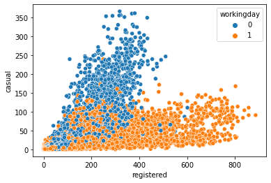

```python
import seaborn as sns

sns.scatterplot(data=df, x='registered', y='casual', hue='workingday')
```

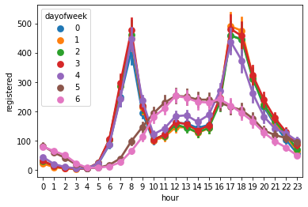

```python
sns.pointplot(data=df, x='hour', y='registered', hue='dayofweek')
```

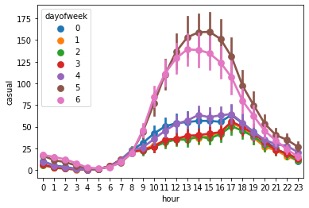

```python
sns.pointplot(data=df, x='hour', y='casual', hue='dayofweek')
```

#### 3. Data Preparation

- train, test split -> Row 분리
- 문제와 정답(feature, label) 분리 -> Column 분리 -> 분석 방향성
- 요일, 날짜, 시간, 날씨에 따라 고객들의 서비스 이용량 증감 파악

```python
df.columns
```

```
Index(['season', 'holiday', 'workingday', 'weather', 'temp', 'atemp',
       'humidity', 'windspeed', 'casual', 'registered', 'count', 'year',
       'month', 'day', 'hour', 'dayofweek'],
      dtype='object')
```

```python
features = ['season', 'holiday', 'workingday', 'weather', 'temp', 'atemp',
       'humidity', 'windspeed', 'year', 'month', 'day', 'hour', 'dayofweek']
label = 'count'

train, test = df[0::2], df[1::2]
```

```python
train, test = train.reset_index(), test.reset_index()
```

```python
train
```

|  | index | season | holiday | workingday | weather | temp | atemp | humidity | windspeed | casual | registered | count | year | month | day | hour | dayofweek |
| --- | --- | --- | --- | --- | --- | --- | --- | --- | --- | --- | --- | --- | --- | --- | --- | --- | --- |
| 0 | 0 | 1 | 0 | 0 | 1 | 9.84 | 14.395 | 81 | 0.0000 | 3 | 13 | 16 | 2011 | 1 | 1 | 0 | 5 |
| 1 | 2 | 1 | 0 | 0 | 1 | 9.02 | 13.635 | 80 | 0.0000 | 5 | 27 | 32 | 2011 | 1 | 1 | 2 | 5 |
| 2 | 4 | 1 | 0 | 0 | 1 | 9.84 | 14.395 | 75 | 0.0000 | 0 | 1 | 1 | 2011 | 1 | 1 | 4 | 5 |
| 3 | 6 | 1 | 0 | 0 | 1 | 9.02 | 13.635 | 80 | 0.0000 | 2 | 0 | 2 | 2011 | 1 | 1 | 6 | 5 |
| 4 | 8 | 1 | 0 | 0 | 1 | 9.84 | 14.395 | 75 | 0.0000 | 1 | 7 | 8 | 2011 | 1 | 1 | 8 | 5 |
| ... | ... | ... | ... | ... | ... | ... | ... | ... | ... | ... | ... | ... | ... | ... | ... | ... | ... |
| 5438 | 10876 | 4 | 0 | 1 | 1 | 17.22 | 21.210 | 50 | 12.9980 | 33 | 185 | 218 | 2012 | 12 | 19 | 14 | 2 |
| 5439 | 10878 | 4 | 0 | 1 | 1 | 17.22 | 21.210 | 50 | 23.9994 | 37 | 297 | 334 | 2012 | 12 | 19 | 16 | 2 |
| 5440 | 10880 | 4 | 0 | 1 | 1 | 15.58 | 19.695 | 50 | 23.9994 | 23 | 546 | 569 | 2012 | 12 | 19 | 18 | 2 |
| 5441 | 10882 | 4 | 0 | 1 | 1 | 14.76 | 17.425 | 57 | 15.0013 | 10 | 231 | 241 | 2012 | 12 | 19 | 20 | 2 |
| 5442 | 10884 | 4 | 0 | 1 | 1 | 13.94 | 17.425 | 61 | 6.0032 | 12 | 117 | 129 | 2012 | 12 | 19 | 22 | 2 |

5443 rows × 17 columns

```python
X_train, y_train = train[features], train[label]
X_test, y_test = test[features], test[label]
```

#### 4. Modeling

**Model Planning**

- 지도학습의 사례 2가지(객관식, 주관식)
- Classification(분류): 객관식(경우의 수)
- Regression(회귀): 주관식(숫자)
- 현 데이터셋은 숫자를 공부하는 것이므로 회귀문제
- 현재 분석 방향성: 고객들의 이용량(숫자)이 label이므로 회귀문제
- 알고리즘 선택할 때 이름과 세부 설명상 수식어로 판단하는 방법: Regressor -> 회귀모델, Classifier -> 분류모델
- 단, Logistic Regression은 위 규칙에서 예외

**Model Building**

- 모델을 가져와 생성(학습하기 전 단계)
- 모델 학습(학습용 데이터 이용)
- 평가지표 적용(학습용 시험용 둘 다 적용)

```python
# scikit-learn
from sklearn.ensemble import RandomForestRegressor as rf

# 알고리즘 생성해 model 변수로 사용
model = rf()

# fitting(적합, 학습, fit 다양하게 표현)
# 문제집을 가지고 학습하는 개념으로 문제(X_train)와 답지(y_train)가 필요
model.fit(X_train, y_train)

# 시험보고 점수 확인
# 학습용 문제지와 정답지를 이용해 문제풀고 점수 확인
train_score = model.score(X_train, y_train)
# 시험용 문제지와 정답지를 이용해 문제풀고 점수 확인
test_score = model.score(X_test, y_test)

# 평가지표: R-Squared(R2)
print(train_score, test_score)
```

```
0.9918552079188799 0.9242655395306252
```